# Tugas Pertemuan 1

## Eksplorasi data latih

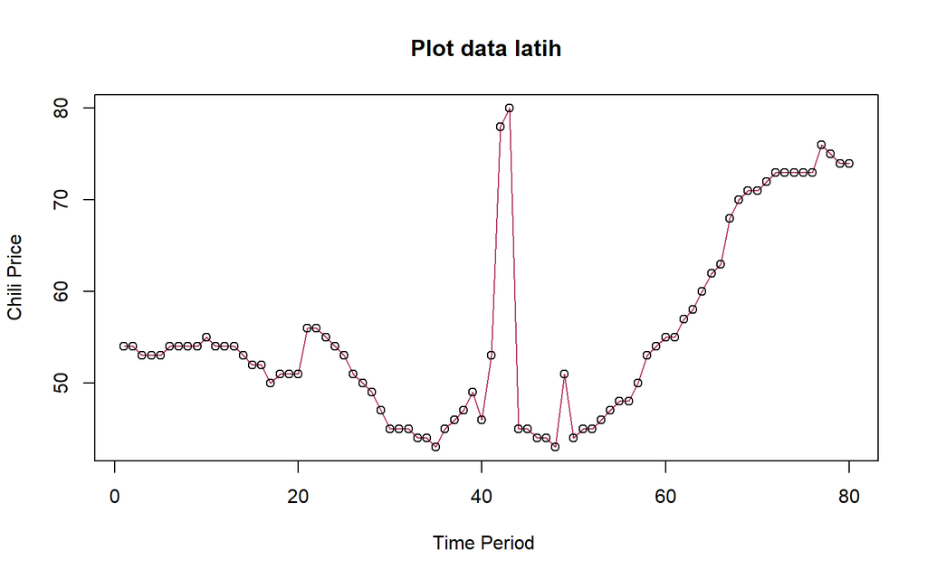

```r
plot(train_ma.ts, xlab = "Time Period ", ylab="Chili Price", col="maroon", main="Plot data latih", pch = 16)
points(train_ma.ts)
```

## Eksplorasi data uji

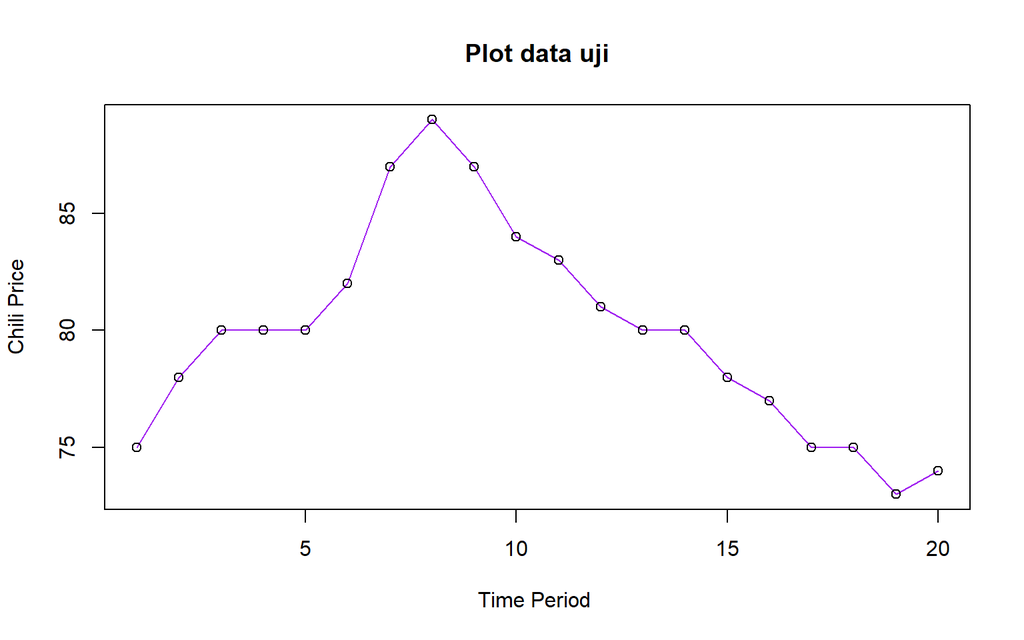

```r
plot(test_ma.ts, xlab = "Time Period ", ylab="Chili Price", col="purple", main="Plot data uji")
points(test_ma.ts)
```

## SMA

```r
data.sma<-SMA(train_ma.ts, n=3)
data.sma
```

```
## Time Series:
## Start = 1
## End = 80
## Frequency = 1
##  [1]       NA       NA 53.66667 53.33333 53.00000 53.33333 53.66667 54.00000
##  [9] 54.00000 54.33333 54.33333 54.33333 54.00000 53.66667 53.00000 52.33333
## [17] 51.33333 51.00000 50.66667 51.00000 52.66667 54.33333 55.66667 55.00000
## [25] 54.00000 52.66667 51.33333 50.00000 48.66667 47.00000 45.66667 45.00000
## [33] 44.66667 44.33333 43.66667 44.00000 44.66667 46.00000 47.33333 47.33333
## [41] 49.33333 59.00000 70.33333 67.66667 56.66667 44.66667 44.33333 43.66667
## [49] 46.00000 46.00000 46.66667 44.66667 45.33333 46.00000 47.00000 47.66667
## [57] 48.66667 50.33333 52.33333 54.00000 54.66667 55.66667 56.66667 58.33333
## [65] 60.00000 61.66667 64.33333 67.00000 69.66667 70.66667 71.33333 72.00000
## [73] 72.66667 73.00000 73.00000 73.00000 74.00000 74.66667 75.00000 74.33333
```

```r
data.ramal<-c(NA,data.sma)
data.ramal #forecast 1 periode ke depan
```

```
##  [1]       NA       NA       NA 53.66667 53.33333 53.00000 53.33333 53.66667
##  [9] 54.00000 54.00000 54.33333 54.33333 54.33333 54.00000 53.66667 53.00000
## [17] 52.33333 51.33333 51.00000 50.66667 51.00000 52.66667 54.33333 55.66667
## [25] 55.00000 54.00000 52.66667 51.33333 50.00000 48.66667 47.00000 45.66667
## [33] 45.00000 44.66667 44.33333 43.66667 44.00000 44.66667 46.00000 47.33333
## [41] 47.33333 49.33333 59.00000 70.33333 67.66667 56.66667 44.66667 44.33333
## [49] 43.66667 46.00000 46.00000 46.66667 44.66667 45.33333 46.00000 47.00000
## [57] 47.66667 48.66667 50.33333 52.33333 54.00000 54.66667 55.66667 56.66667
## [65] 58.33333 60.00000 61.66667 64.33333 67.00000 69.66667 70.66667 71.33333
## [73] 72.00000 72.66667 73.00000 73.00000 73.00000 74.00000 74.66667 75.00000
## [81] 74.33333
```

```r
data.gab <- cbind(
  aktual    = c(train_ma.ts),
  pemulusan = c(data.sma),
  ramalan   = c(data.ramal[1:length(train_ma.ts)])
)

data.gab
```

```
##       aktual pemulusan  ramalan
##  [1,]     54        NA       NA
##  [2,]     54        NA       NA
##  [3,]     53  53.66667       NA
##  [4,]     53  53.33333 53.66667
##  [5,]     53  53.00000 53.33333
##  [6,]     54  53.33333 53.00000
##  [7,]     54  53.66667 53.33333
##  [8,]     54  54.00000 53.66667
##  [9,]     54  54.00000 54.00000
## [10,]     55  54.33333 54.00000
## [11,]     54  54.33333 54.33333
## [12,]     54  54.33333 54.33333
## [13,]     54  54.00000 54.33333
## [14,]     53  53.66667 54.00000
```

[output cut: 66 more lines]

## Plot data deret waktu dari hasil peramalan

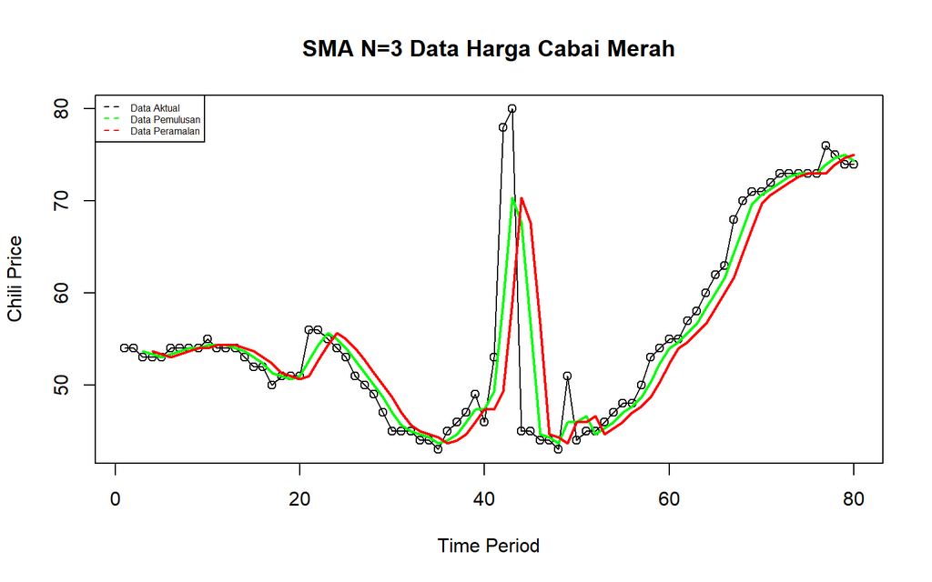

```r
# Plot data aktual (data latih)
ts.plot(train_ma.ts,
        xlab = "Time Period",
        ylab = "Chili Price",
        main = "SMA N=3 Data Harga Cabai Merah")
points(train_ma.ts)

lines(data.gab[,2], col = "green", lwd = 2)
lines(data.gab[,3], col = "red", lwd = 2)

legend("topleft",
       legend = c("Data Aktual", "Data Pemulusan", "Data Peramalan"),
       lty = 8,
       col = c("black", "green", "red"),
       cex = 0.5)
```

## Menghitung Error

```r
error_train.sma = train_ma.ts-data.ramal[1:length(train_ma.ts)]

SSE_train.sma = sum(error_train.sma[5:length(train_ma.ts)]^2)
MSE_train.sma = mean(error_train.sma[5:length(train_ma.ts)]^2)
MAPE_train.sma = mean(abs((error_train.sma[5:length(train_ma.ts)]/train_ma.ts[5:length(train_ma.ts)])*100))

akurasi_train.sma <- matrix(c(SSE_train.sma, MSE_train.sma, MAPE_train.sma))
row.names(akurasi_train.sma)<- c("SSE", "MSE", "MAPE")
colnames(akurasi_train.sma) <- c("Akurasi n = 3")
akurasi_train.sma
```

```
##      Akurasi n = 3
## SSE    3012.000000
## MSE      39.631579
## MAPE      5.907058
```

```r
# Nilai peramalan SMA untuk data uji menggunakan nilai rata-rata terakhir dari data latih
ramalan_test <- rep(data.sma[length(train_ma.ts)], length(test_ma.ts))
error_test.sma <- test_ma.ts - ramalan_test

SSE_test.sma  <- sum(error_test.sma^2) # # Menghitung ukuran kebaikan model (SSE, MSE, MAPE)
MSE_test.sma  <- mean(error_test.sma^2)
MAPE_test.sma <- mean(abs(error_test.sma / test_ma.ts) * 100)

akurasi_test.sma <- matrix(c(SSE_test.sma, MSE_test.sma, MAPE_test.sma))
row.names(akurasi_test.sma) <- c("SSE", "MSE", "MAPE")
colnames(akurasi_test.sma)  <- c("Akurasi n = 3")

akurasi_test.sma
```

```
##      Akurasi n = 3
## SSE    1005.555556
## MSE      50.277778
## MAPE      6.917655
```

Perhitungan akurasi menggunakan data latih menghasilkan nilai MAPE yang kurang dari 10% sehingga nilai akurasi ini dapat dikategorikan sebagai sangat baik.

## DMA

```r
dma <- SMA(data.sma, n = 3)
At <- 2 * data.sma - dma
Bt <- (2 / (3 - 1)) * (data.sma - dma)
data.dma <- At + Bt
data.ramal2 <- c(NA, data.dma)

t <- 1:length(test_ma.ts) # t = 1 sampai 20
f <- c()

for (i in t) {
  f[i] <- At[length(At)] + Bt[length(Bt)] * i
}

data.gab2 <- cbind(
  aktual     = c(train_ma.ts, rep(NA, length(test_ma.ts))),
  pemulusan1 = c(data.sma, rep(NA, length(test_ma.ts))),
  pemulusan2 = c(dma, rep(NA, length(test_ma.ts))),
  At         = c(At, rep(NA, length(test_ma.ts))),
  Bt         = c(Bt, rep(NA, length(test_ma.ts))),
  ramalan    = c(data.ramal2[1:length(train_ma.ts)], f)
)

data.gab2
```

```
##        aktual pemulusan1 pemulusan2       At            Bt  ramalan
##   [1,]     54         NA         NA       NA            NA       NA
##   [2,]     54         NA         NA       NA            NA       NA
##   [3,]     53   53.66667         NA       NA            NA       NA
##   [4,]     53   53.33333         NA       NA            NA       NA
##   [5,]     53   53.00000   53.33333 52.66667 -3.333333e-01       NA
##   [6,]     54   53.33333   53.22222 53.44444  1.111111e-01 52.33333
##   [7,]     54   53.66667   53.33333 54.00000  3.333333e-01 53.55556
##   [8,]     54   54.00000   53.66667 54.33333  3.333333e-01 54.33333
##   [9,]     54   54.00000   53.88889 54.11111  1.111111e-01 54.66667
##  [10,]     55   54.33333   54.11111 54.55556  2.222222e-01 54.22222
##  [11,]     54   54.33333   54.22222 54.44444  1.111111e-01 54.77778
##  [12,]     54   54.33333   54.33333 54.33333 -7.105427e-15 54.55556
##  [13,]     54   54.00000   54.22222 53.77778 -2.222222e-01 54.33333
##  [14,]     53   53.66667   54.00000 53.33333 -3.333333e-01 53.55556
```

[output cut: 86 more lines]

## Plot data deret waktu dari hasil peramalan

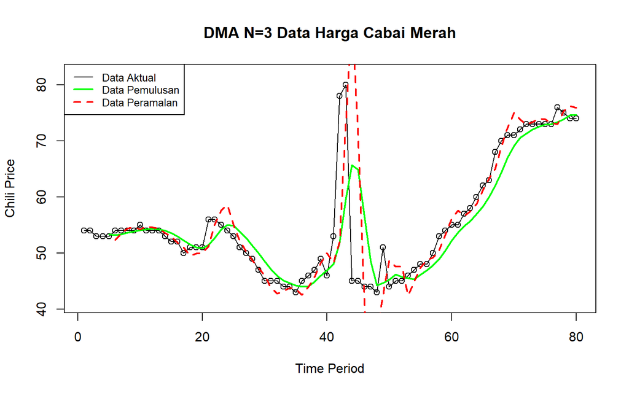

```r
ts.plot(train_ma.ts,
        xlab = "Time Period",
        ylab = "Chili Price",
        main = "DMA N=3 Data Harga Cabai Merah",
        ylim = c(min(train_ma.ts, na.rm = TRUE) - 2, max(train_ma.ts, na.rm = TRUE) + 2))
points(train_ma.ts)

lines(data.gab2[, 3], col = "green", lwd = 2)
lines(data.gab2[1:80, 6], col = "red", lwd = 2, lty = 2)

legend("topleft",
       legend = c("Data Aktual", "Data Pemulusan", "Data Peramalan"),
       lty = c(1, 1, 2),
       col = c("black", "green", "red"),
       lwd = c(1, 2, 2),
       cex = 0.8)
```

## Menghitung error

```r
error_train.dma <- train_ma.ts - data.ramal2[1:length(train_ma.ts)]

SSE_train.dma  <- sum(error_train.dma[6:length(train_ma.ts)]^2)
MSE_train.dma  <- mean(error_train.dma[6:length(train_ma.ts)]^2)
MAPE_train.dma <- mean(abs(error_train.dma[6:length(train_ma.ts)] / train_ma.ts[6:length(train_ma.ts)]) * 100)

akurasi_train.dma <- matrix(c(SSE_train.dma, MSE_train.dma, MAPE_train.dma))
row.names(akurasi_train.dma) <- c("SSE", "MSE", "MAPE")
colnames(akurasi_train.dma)  <- c("Akurasi n = 3")

akurasi_train.dma
```

```
##      Akurasi n = 3
## SSE    4531.691358
## MSE      60.422551
## MAPE      6.452164
```

Perhitungan akurasi pada data latih menggunakan nilai MAPE menghasilkan nilai MAPE yang kurang dari 10% sehingga dikategorikan sangat baik. Selanjutnya, perhitungan nilai akurasi dilakukan pada data uji.

```r
ramalan_test.dma <- data.gab2[81:100, 6]
error_test.dma <- test_ma.ts - ramalan_test.dma

SSE_test.dma  <- sum(error_test.dma^2)
MSE_test.dma  <- mean(error_test.dma^2)
MAPE_test.dma <- mean(abs(error_test.dma / test_ma.ts) * 100)

akurasi_test.dma <- matrix(c(SSE_test.dma, MSE_test.dma, MAPE_test.dma))
row.names(akurasi_test.dma) <- c("SSE", "MSE", "MAPE")
colnames(akurasi_test.dma)  <- c("Akurasi n = 3")

akurasi_test.dma
```

```
##      Akurasi n = 3
## SSE     2084.88889
## MSE      104.24444
## MAPE      11.55919
```

Pada data latih dan data uji, metode SMA lebih baik dibandingkan dengan metode DMA.

# Single Exponential Smoothing & Double Exponential Smoothing

```r
ses.model <- ses(train_ma.ts, h = length(test_ma.ts))
summary(ses.model)
```

```
##
## Forecast method: Simple exponential smoothing
##
## Model Information:
## Simple exponential smoothing
##
## Call:
## ses(y = train_ma.ts, h = length(test_ma.ts))
##
##   Smoothing parameters:
##     alpha = 0.9999
##
##   Initial states:
##     l = 53.9932
##
##   sigma:  5.2721
##
##      AIC     AICc      BIC
## 620.5256 620.8414 627.6717
##
## Error measures:
##                     ME     RMSE      MAE         MPE     MAPE      MASE
## Training set 0.2501105 5.205792 1.950205 -0.01714034 3.629501 0.9876041
##                    ACF1
## Training set 0.04811271
##
## Forecasts:
##     Point Forecast    Lo 80     Hi 80    Lo 95     Hi 95
##  81             74 67.24352  80.75648 63.66685  84.33315
##  82             74 64.44537  83.55463 59.38745  88.61255
##  83             74 62.29821  85.70179 56.10366  91.89634
##  84             74 60.48805  87.51195 53.33526  94.66474
##  85             74 58.89326  89.10674 50.89623  97.10377
##  86             74 57.45145  90.54855 48.69117  99.30883
##  87             74 56.12556  91.87444 46.66341 101.33659
##  88             74 54.89146  93.10854 44.77600 103.22400
##  89             74 53.73236  94.26764 43.00331 104.99669
##  90             74 52.63605  95.36395 41.32666 106.67334
##  91             74 51.59332  96.40668 39.73194 108.26806
##  92             74 50.59701  97.40299 38.20821 109.79179
##  93             74 49.64141  98.35859 36.74675 111.25325
##  94             74 48.72191  99.27809 35.34049 112.65951
##  95             74 47.83470 100.16530 33.98363 114.01637
##  96             74 46.97661 101.02339 32.67129 115.32871
##  97             74 46.14493 101.85507 31.39935 116.60065
##  98             74 45.33738 102.66262 30.16431 117.83569
##  99             74 44.55197 103.44803 28.96312 119.03688
## 100             74 43.78697 104.21303 27.79315 120.20685
```

```r
ses.fitted <- ses.model$fitted
ses.fq     <- ses.model$mean

data.gab.ses <- cbind(
  aktual    = c(train_ma.ts, test_ma.ts),
  pemulusan = c(ses.fitted, rep(NA, length(test_ma.ts))),
  ramalan   = c(rep(NA, length(train_ma.ts)), ses.fq)
)

data.gab.ses
```

```
##        aktual pemulusan ramalan
##   [1,]     54  53.99316      NA
##   [2,]     54  54.00000      NA
##   [3,]     53  54.00000      NA
##   [4,]     53  53.00010      NA
##   [5,]     53  53.00000      NA
##   [6,]     54  53.00000      NA
##   [7,]     54  53.99990      NA
##   [8,]     54  54.00000      NA
##   [9,]     54  54.00000      NA
##  [10,]     55  54.00000      NA
##  [11,]     54  54.99990      NA
##  [12,]     54  54.00010      NA
##  [13,]     54  54.00000      NA
##  [14,]     53  54.00000      NA
```

[output cut: 86 more lines]

## Eksplorasi data

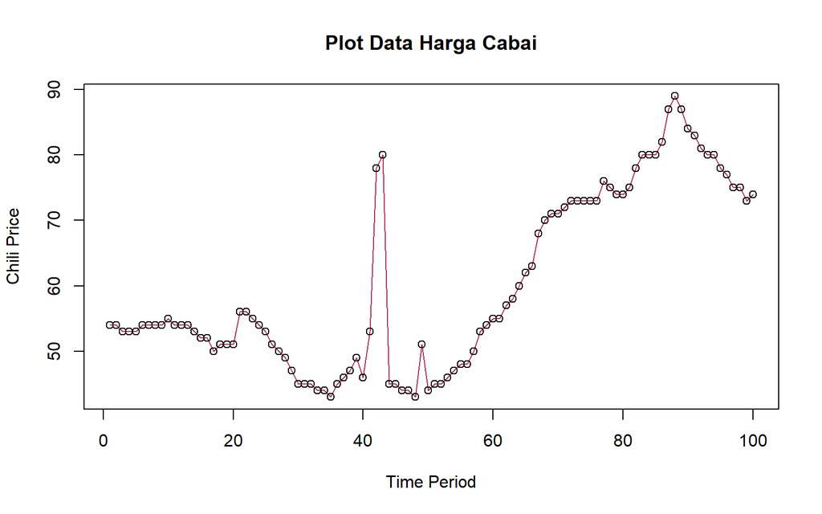

```r
plot(data1.ts, col = "maroon", main = "Plot Data Harga Cabai", ylab = "Chili Price", xlab = "Time Period")
points(data1.ts)
```

## Eksplorasi data latih

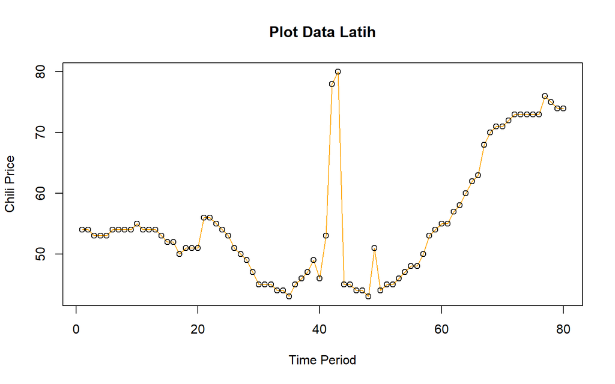

```r
plot(train_ma.ts, col = "orange", main = "Plot Data Latih", ylab = "Chili Price", xlab = "Time Period")
points(train_ma.ts)
```

## Plot data uji

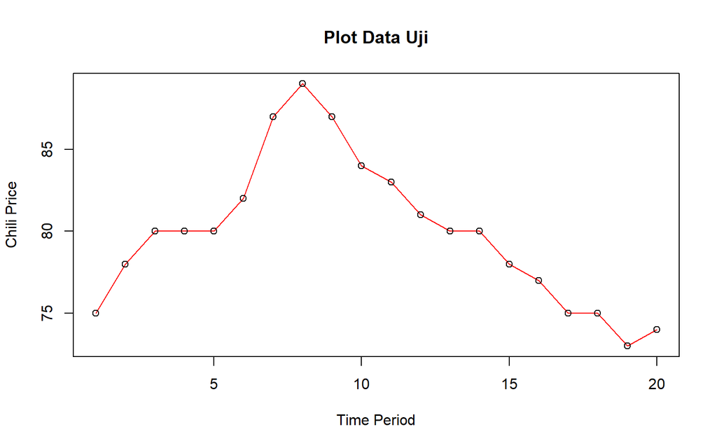

```r
plot(test_ma.ts, col = "red", main = "Plot Data Uji", ylab = "Chili Price", xlab = "Time Period")
points(test_ma.ts)
```

## SES

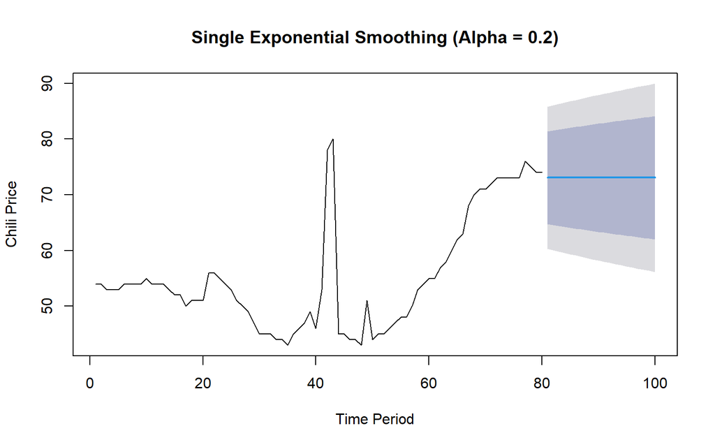

```r
ses.data <- ses(train_ma.ts, h = length(test_ma.ts), alpha = 0.2)
plot(ses.data, main = "Single Exponential Smoothing (Alpha = 0.2)", ylab = "Chili Price", xlab = "Time Period")
```

```r
ses.data
```

```
##     Point Forecast    Lo 80    Hi 80    Lo 95    Hi 95
##  81        73.0526 64.73090 81.37429 60.32567 85.77953
##  82        73.0526 64.56610 81.53909 60.07362 86.03157
##  83        73.0526 64.40444 81.70075 59.82638 86.27881
##  84        73.0526 64.24575 81.85945 59.58368 86.52152
##  85        73.0526 64.08986 82.01534 59.34527 86.75992
##  86        73.0526 63.93664 82.16856 59.11094 86.99425
##  87        73.0526 63.78595 82.31924 58.88049 87.22471
##  88        73.0526 63.63768 82.46752 58.65372 87.45148
##  89        73.0526 63.49170 82.61349 58.43047 87.67473
##  90        73.0526 63.34792 82.75728 58.21057 87.89462
##  91        73.0526 63.20624 82.89896 57.99389 88.11131
##  92        73.0526 63.06657 83.03863 57.78028 88.32492
##  93        73.0526 62.92882 83.17637 57.56962 88.53558
##  94        73.0526 62.79293 83.31227 57.36178 88.74341
##  95        73.0526 62.65881 83.44639 57.15667 88.94853
##  96        73.0526 62.52640 83.57880 56.95416 89.15103
##  97        73.0526 62.39563 83.70956 56.75417 89.35102
##  98        73.0526 62.26645 83.83874 56.55661 89.54859
##  99        73.0526 62.13880 83.96640 56.36138 89.74381
## 100        73.0526 62.01262 84.09257 56.16841 89.93678
```

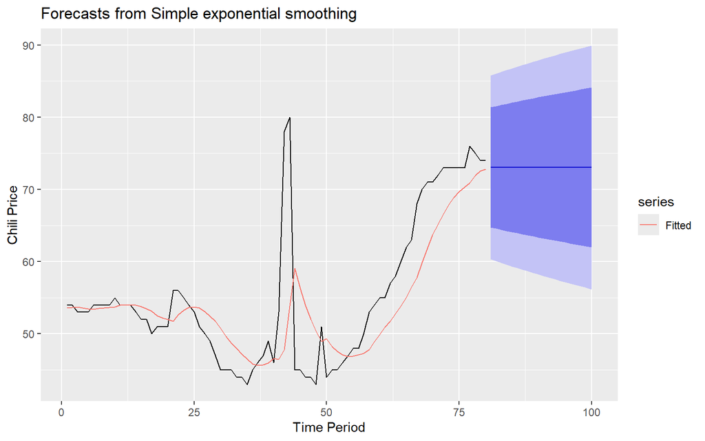

```r
autoplot(ses.data) +
  autolayer(fitted(ses.data), series="Fitted") +
  ylab("Chili Price") + xlab("Time Period")
```

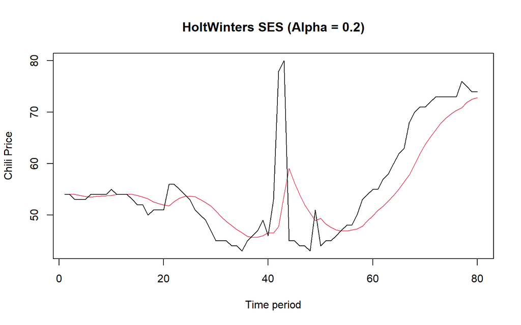

```r
ses1 <- HoltWinters(train_ma.ts, gamma = FALSE, beta = FALSE, alpha = 0.2)
plot(ses1, main = "HoltWinters SES (Alpha = 0.2)", ylab = "Chili Price", xlab = "Time period")
```

```r
ramalan1 <- forecast(ses1, h = length(test_ma.ts))
ramalan1
```

```
##     Point Forecast    Lo 80    Hi 80    Lo 95    Hi 95
##  81        73.0526 64.87696 81.22823 60.54904 85.55615
##  82        73.0526 64.71505 81.39014 60.30142 85.80377
##  83        73.0526 64.55623 81.54897 60.05852 86.04667
##  84        73.0526 64.40032 81.70488 59.82008 86.28512
##  85        73.0526 64.24717 81.85803 59.58586 86.51934
##  86        73.0526 64.09664 82.00856 59.35564 86.74956
##  87        73.0526 63.94860 82.15660 59.12923 86.97597
##  88        73.0526 63.80292 82.30227 58.90644 87.19875
##  89        73.0526 63.65951 82.44569 58.68711 87.41809
##  90        73.0526 63.51825 82.58694 58.47107 87.63412
##  91        73.0526 63.37906 82.72614 58.25819 87.84700
##  92        73.0526 63.24184 82.86336 58.04833 88.05686
##  93        73.0526 63.10651 82.99869 57.84137 88.26383
##  94        73.0526 62.97300 83.13220 57.63718 88.46801
##  95        73.0526 62.84123 83.26396 57.43566 88.66953
##  96        73.0526 62.71115 83.39405 57.23671 88.86848
##  97        73.0526 62.58268 83.52252 57.04023 89.06496
##  98        73.0526 62.45576 83.64943 56.84614 89.25906
##  99        73.0526 62.33035 83.77484 56.65434 89.45086
## 100        73.0526 62.20639 83.89880 56.46476 89.64044
```

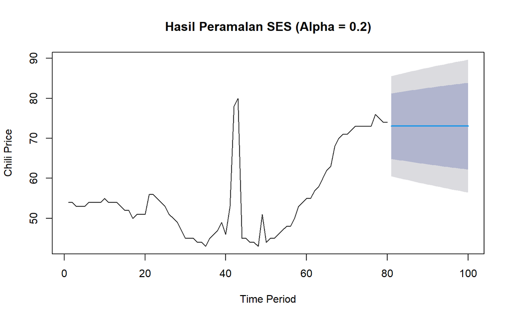

```r
plot(ramalan1, main = "Hasil Peramalan SES (Alpha = 0.2)", ylab = "Chili Price", xlab = "Time Period")
```

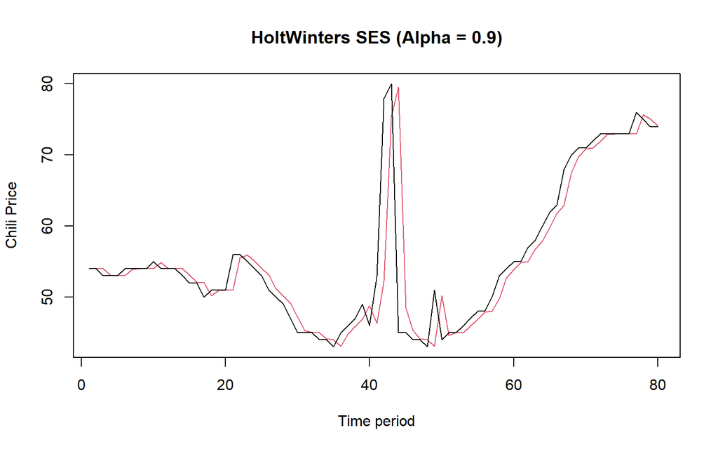

```r
ses2<- HoltWinters(train_ma.ts, gamma = FALSE, beta = FALSE, alpha = 0.9)
plot(ses2, main = "HoltWinters SES (Alpha = 0.9)", ylab = "Chili Price", xlab = "Time period")
```

```r
ramalan2 <- forecast(ses2, h = length(test_ma.ts))
ramalan2
```

```
##     Point Forecast    Lo 80     Hi 80    Lo 95     Hi 95
##  81        74.0107 67.22222  80.79918 63.62861  84.39279
##  82        74.0107 64.87773  83.14367 60.04303  87.97837
##  83        74.0107 63.02258  84.99882 57.20582  90.81558
##  84        74.0107 61.43825  86.58315 54.78280  93.23860
##  85        74.0107 60.03236  87.98904 52.63267  95.38873
##  86        74.0107 58.75548  89.26592 50.67986  97.34154
##  87        74.0107 57.57752  90.44388 48.87832  99.14308
##  88        74.0107 56.47853  91.54287 47.19756 100.82384
##  89        74.0107 55.44448  92.57692 45.61611 102.40529
##  90        74.0107 54.46505  93.55635 44.11821 103.90319
##  91        74.0107 53.53242  94.48898 42.69187 105.32953
##  92        74.0107 52.64045  95.38095 41.32772 106.69368
##  93        74.0107 51.78425  96.23715 40.01827 108.00313
##  94        74.0107 50.95982  97.06158 38.75743 109.26397
##  95        74.0107 50.16389  97.85751 37.54015 110.48125
##  96        74.0107 49.39367  98.62773 36.36220 111.65920
##  97        74.0107 48.64683  99.37457 35.22001 112.80139
##  98        74.0107 47.92136 100.10004 34.11050 113.91090
##  99        74.0107 47.21553 100.80587 33.03103 114.99037
## 100        74.0107 46.52782 101.49358 31.97926 116.04214
```

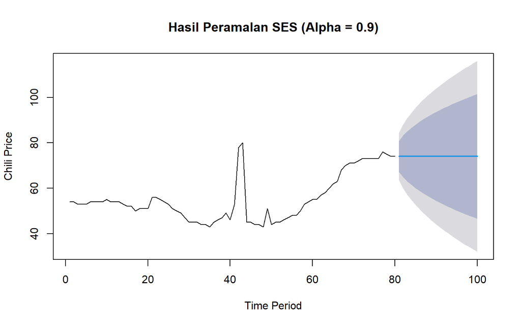

```r
plot(ramalan2, main = "Hasil Peramalan SES (Alpha = 0.9)", ylab = "Chili Price", xlab = "Time Period")
```

## SES optimum

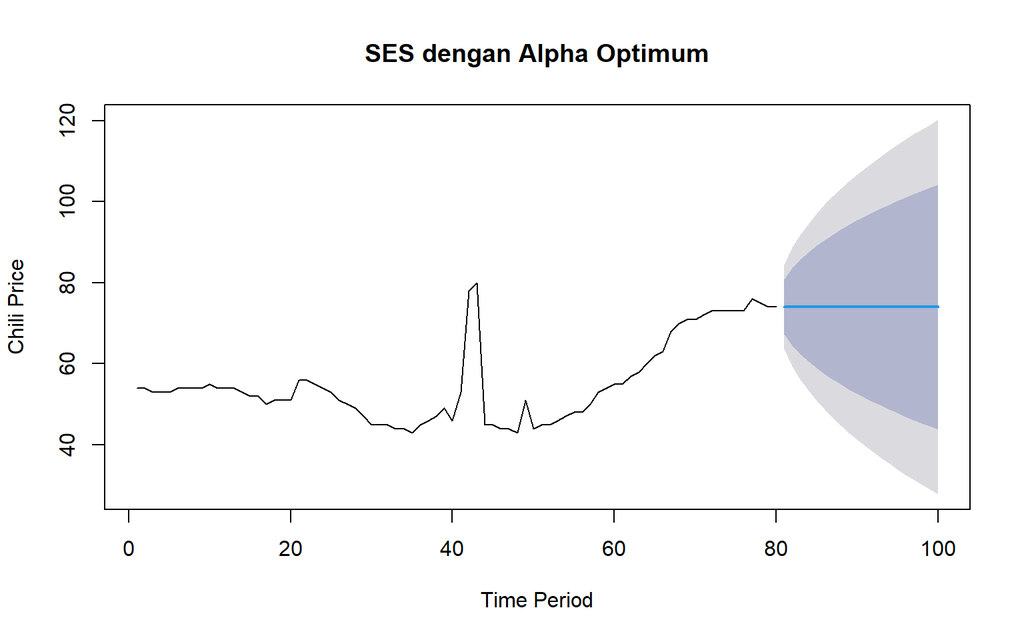

```r
ses.opt <- ses(train_ma.ts, h = length(test_ma.ts), alpha = NULL)
plot(ses.opt, main = "SES dengan Alpha Optimum", ylab = "Chili Price", xlab = "Time Period")
```

```r
ses.opt
```

```
##     Point Forecast    Lo 80     Hi 80    Lo 95     Hi 95
##  81             74 67.24352  80.75648 63.66685  84.33315
##  82             74 64.44537  83.55463 59.38745  88.61255
##  83             74 62.29821  85.70179 56.10366  91.89634
##  84             74 60.48805  87.51195 53.33526  94.66474
##  85             74 58.89326  89.10674 50.89623  97.10377
##  86             74 57.45145  90.54855 48.69117  99.30883
##  87             74 56.12556  91.87444 46.66341 101.33659
##  88             74 54.89146  93.10854 44.77600 103.22400
##  89             74 53.73236  94.26764 43.00331 104.99669
##  90             74 52.63605  95.36395 41.32666 106.67334
##  91             74 51.59332  96.40668 39.73194 108.26806
##  92             74 50.59701  97.40299 38.20821 109.79179
##  93             74 49.64141  98.35859 36.74675 111.25325
##  94             74 48.72191  99.27809 35.34049 112.65951
##  95             74 47.83470 100.16530 33.98363 114.01637
##  96             74 46.97661 101.02339 32.67129 115.32871
##  97             74 46.14493 101.85507 31.39935 116.60065
##  98             74 45.33738 102.66262 30.16431 117.83569
##  99             74 44.55197 103.44803 28.96312 119.03688
## 100             74 43.78697 104.21303 27.79315 120.20685
```

```r
HWopt <- HoltWinters(train_ma.ts, gamma = FALSE, beta = FALSE, alpha = NULL)
HWopt
```

```
## Holt-Winters exponential smoothing without trend and without seasonal component.
##
## Call:
## HoltWinters(x = train_ma.ts, alpha = NULL, beta = FALSE, gamma = FALSE)
##
## Smoothing parameters:
##  alpha: 0.9999528
##  beta : FALSE
##  gamma: FALSE
##
## Coefficients:
##   [,1]
## a   74
```

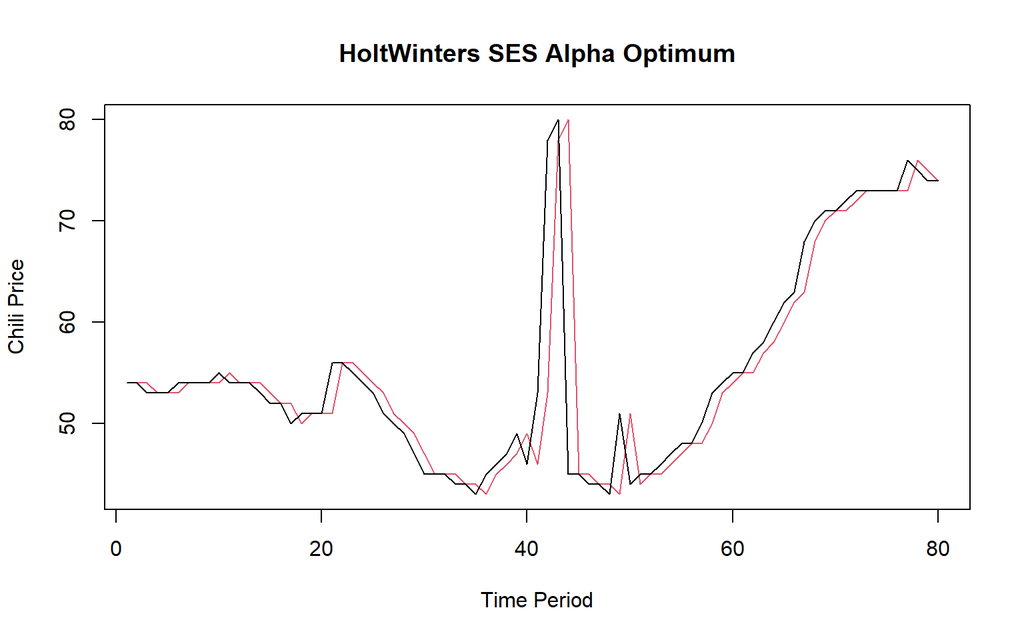

```r
plot(HWopt, main = "HoltWinters SES Alpha Optimum", ylab = "Chili Price", xlab = "Time Period")
```

```r
ramalanopt <- forecast(HWopt, h = length(test_ma.ts))
ramalanopt
```

```
##     Point Forecast    Lo 80     Hi 80    Lo 95     Hi 95
##  81             74 67.25143  80.74857 63.67895  84.32105
##  82             74 64.45631  83.54369 59.40418  88.59582
##  83             74 62.31150  85.68850 56.12399  91.87601
##  84             74 60.50334  87.49666 53.35864  94.64136
##  85             74 58.91031  89.08969 50.92231  97.07769
##  86             74 57.47010  90.52990 48.71970  99.28030
##  87             74 56.14569  91.85431 46.69419 101.30581
##  88             74 54.91295  93.08705 44.80888 103.19112
##  89             74 53.75514  94.24486 43.03816 104.96184
##  90             74 52.66006  95.33994 41.36338 106.63662
##  91             74 51.61849  96.38151 39.77043 108.22957
##  92             74 50.62328  97.37672 38.24840 109.75160
##  93             74 49.66875  98.33125 36.78856 111.21144
##  94             74 48.75027  99.24973 35.38388 112.61612
##  95             74 47.86406 100.13594 34.02852 113.97148
##  96             74 47.00692 100.99308 32.71765 115.28235
##  97             74 46.17617 101.82383 31.44713 116.55287
##  98             74 45.36952 102.63048 30.21347 117.78653
##  99             74 44.58499 103.41501 29.01362 118.98638
## 100             74 43.82084 104.17916 27.84495 120.15505
```

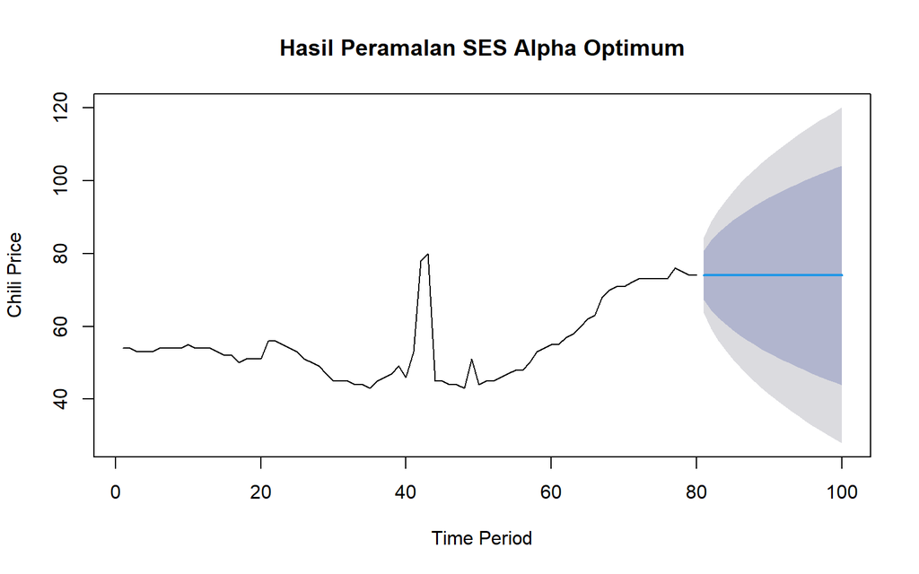

```r
plot(ramalanopt, main = "Hasil Peramalan SES Alpha Optimum", ylab = "Chili Price", xlab = "Time Period")
```

## Akurasi Data Latih

```r
train.ts <- ts(data1$Harga[1:80])
train.ts <- ts(data1[1:80, 1])
# SES dengan alpha = 0.2
SSE1<-ses1$SSE
MSE1<-ses1$SSE/length(train.ts)
RMSE1<-sqrt(MSE1)

akurasi1 <- matrix(c(SSE1,MSE1,RMSE1))
row.names(akurasi1)<- c("SSE", "MSE", "RMSE")
colnames(akurasi1) <- c("Akurasi lamda=0.2")
akurasi1
```

```
##      Akurasi lamda=0.2
## SSE        3289.301321
## MSE          41.116267
## RMSE          6.412197
```

```r
# SES dengan alpha = 0.9
SSE2<-ses2$SSE
MSE2<-ses2$SSE/length(train.ts)
RMSE2<-sqrt(MSE2)

akurasi2 <- matrix(c(SSE2,MSE2,RMSE2))
row.names(akurasi2)<- c("SSE", "MSE", "RMSE")
colnames(akurasi2) <- c("Akurasi lamda=0.9")
akurasi2
```

```
##      Akurasi lamda=0.9
## SSE        2194.865645
## MSE          27.435821
## RMSE          5.237921
```

Berdasarkan nilai SSE, MSE, dan RMSE di antara kedua parameter, nilai parameter $\alpha = 0,9$ menghasilkan akurasi yang lebih baik dibanding $\alpha = 0,2$. Hal ini dilihat dari nilai masing-masing ukuran akurasi yang lebih kecil. Berdasarkan nilai RMSE-nya, hasil ini dapat dikategorikan sebagai peramalan sangat baik.

## Akurasi data uji

```r
n_test <- length(test_ma.ts)

e1   <- as.numeric(ramalan1$mean)[1:n_test] - as.numeric(test_ma.ts) # Menghitung Error
e2   <- as.numeric(ramalan2$mean)[1:n_test] - as.numeric(test_ma.ts)
eopt <- as.numeric(ramalanopt$mean)[1:n_test] - as.numeric(test_ma.ts)

SSEtesting1  <- sum(e1^2, na.rm = TRUE) # Ukuran Kebaikan Model untuk Alpha = 0.2
MSEtesting1  <- mean(e1^2, na.rm = TRUE)
RMSEtesting1 <- sqrt(MSEtesting1)
MAPEtesting1 <- mean(abs(e1 / as.numeric(test_ma.ts)) * 100, na.rm = TRUE)

SSEtesting2  <- sum(e2^2, na.rm = TRUE) # Ukuran Kebaikan Model untuk Alpha = 0.9
MSEtesting2  <- mean(e2^2, na.rm = TRUE)
RMSEtesting2 <- sqrt(MSEtesting2)
MAPEtesting2 <- mean(abs(e2 / as.numeric(test_ma.ts)) * 100, na.rm = TRUE)

SSEtestingopt  <- sum(eopt^2, na.rm = TRUE) # Ukuran Kebaikan Model untuk Alpha Optimum
MSEtestingopt  <- mean(eopt^2, na.rm = TRUE)
RMSEtestingopt <- sqrt(MSEtestingopt)
MAPEtestingopt <- mean(abs(eopt / as.numeric(test_ma.ts)) * 100, na.rm = TRUE)

# Tabel ringkas
akurasitesting_ses <- matrix(
  c(SSEtesting1, MSEtesting1, RMSEtesting1, MAPEtesting1,
    SSEtesting2, MSEtesting2, RMSEtesting2, MAPEtesting2,
    SSEtestingopt, MSEtestingopt, RMSEtestingopt, MAPEtestingopt),
  nrow = 4,
  byrow = FALSE,
  dimnames = list(c("SSE", "MSE", "RMSE", "MAPE (%)"),
                  c("Alpha = 0.2", "Alpha = 0.9", "Alpha Optimum"))
)

akurasitesting_ses
```

```
##          Alpha = 0.2 Alpha = 0.9 Alpha Optimum
## SSE      1323.538429 1079.477090   1081.999999
## MSE        66.176921   53.973855     54.100000
## RMSE        8.134920    7.346690      7.355270
## MAPE (%)    8.304864    7.234859      7.245379
```

Berdasarkan nilai SSE, MSE, RMSE, dan MAPE pada data uji, nilai parameter $/Alpha = 0.9$ menghasilkan akurasi yang paling baik dibandingkan parameter $/Alpha = 0.2$ maupun Alpha Optimum.

## DES

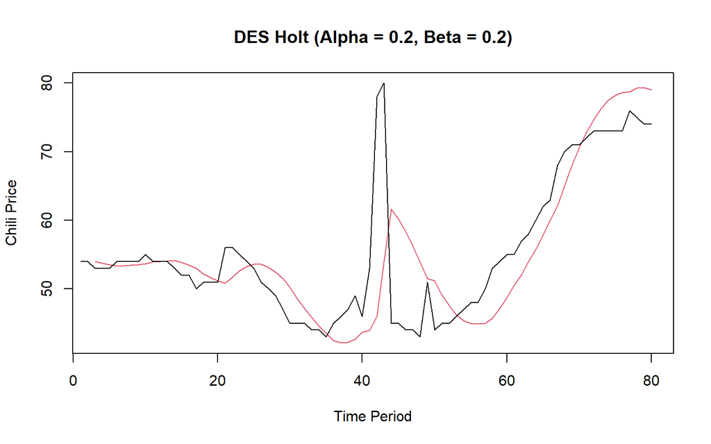

```r
des.1 <- HoltWinters(train_ma.ts, gamma = FALSE, alpha = 0.2, beta = 0.2)
plot(des.1, main = "DES Holt (Alpha = 0.2, Beta = 0.2)", ylab = "Chili Price", xlab = "Time Period")
```

```r
ramalandes1 <- forecast(des.1, h = length(test_ma.ts))
ramalandes1
```

```
##     Point Forecast    Lo 80     Hi 80    Lo 95     Hi 95
##  81       78.55597 69.74543  87.36650 65.08142  92.03052
##  82       79.08326 70.02254  88.14399 65.22608  92.94045
##  83       79.61056 70.22000  89.00112 65.24894  93.97218
##  84       80.13785 70.33319  89.94252 65.14291  95.13279
##  85       80.66515 70.36021  90.97008 64.90511  96.42518
##  86       81.19244 70.30154  92.08334 64.53624  97.84864
##  87       81.71973 70.15946  93.28001 64.03981  99.39966
##  88       82.24703 69.93748  94.55658 63.42120 101.07286
##  89       82.77432 69.63983  95.90882 62.68685 102.86180
##  90       83.30162 69.27100  97.33224 61.84364 104.75960
##  91       83.82891 68.83547  98.82236 60.89841 106.75941
##  92       84.35621 68.33750 100.37491 59.85771 108.85470
##  93       84.88350 67.78108 101.98592 58.72760 111.03940
##  94       85.41080 67.16980 103.65179 57.51360 113.30799
##  95       85.93809 66.50692 105.36926 56.22068 115.65550
##  96       86.46538 65.79534 107.13543 54.85328 118.07749
##  97       86.99268 65.03765 108.94771 53.41536 120.57000
##  98       87.51997 64.23615 110.80380 51.91044 123.12951
##  99       88.04727 63.39288 112.70165 50.34164 125.75290
## 100       88.57456 62.50967 114.63945 48.71175 128.43737
```

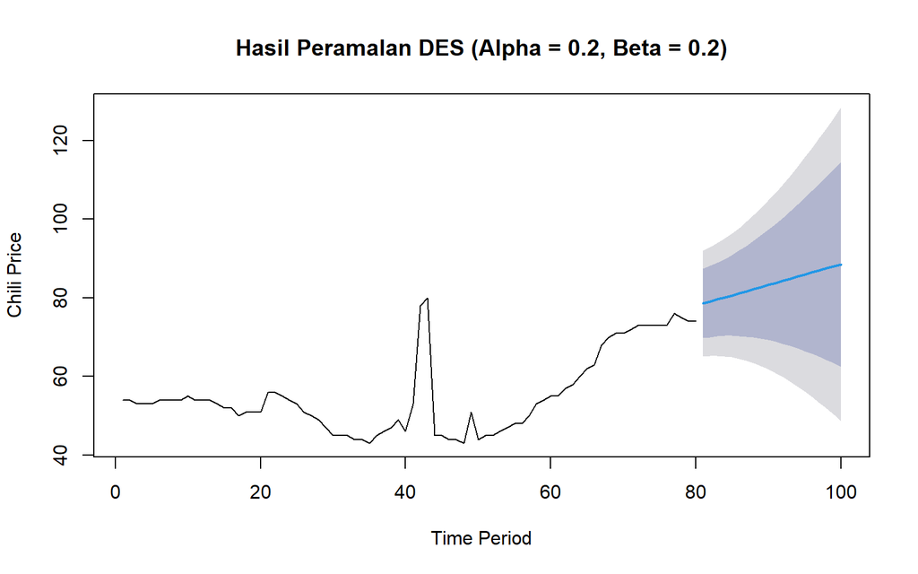

```r
plot(ramalandes1, main = "Hasil Peramalan DES (Alpha = 0.2, Beta = 0.2)", ylab = "Chili Price", xlab = "Time Period")
```

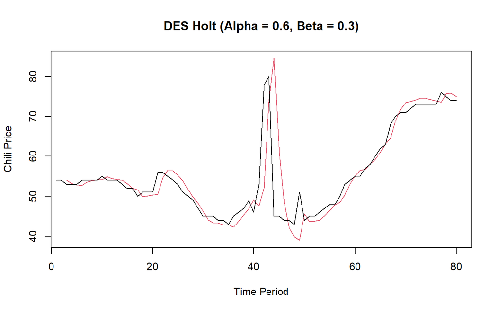

```r
des.2 <- HoltWinters(train_ma.ts, gamma = FALSE, alpha = 0.6, beta = 0.3) # DES dengan Alpha = 0.6 dan Beta = 0.3
plot(des.2, main = "DES Holt (Alpha = 0.6, Beta = 0.3)", ylab = "Chili Price", xlab = "Time Period")
```

```r
ramalandes2 <- forecast(des.2, h = length(test_ma.ts))
ramalandes2
```

```
##     Point Forecast      Lo 80     Hi 80      Lo 95     Hi 95
##  81       74.42233  66.542061  82.30259  62.370502  86.47415
##  82       74.46625  64.472281  84.46021  59.181796  89.75070
##  83       74.51017  61.975838  87.04449  55.340566  93.67977
##  84       74.55409  59.132910  89.97526  50.969433  98.13874
##  85       74.59801  55.996576  93.19944  46.149574 103.04644
##  86       74.64193  52.602530  96.68132  40.935579 108.34827
##  87       74.68585  48.975888 100.39581  35.365858 114.00584
##  88       74.72977  45.135203 104.32433  29.468788 119.99075
##  89       74.77369  41.094798 108.45258  23.266271 126.28110
##  90       74.81761  36.866136 112.76908  16.775841 132.85937
##  91       74.86153  32.458675 117.26438  10.011961 139.71109
##  92       74.90545  27.880403 121.93049   2.986848 146.82405
##  93       74.94937  23.138202 126.76053  -4.288972 154.18771
##  94       74.99329  18.238094 131.74848 -11.806291 161.79287
##  95       75.03721  13.185415 136.88900 -19.556946 169.63136
##  96       75.08113   7.984946 142.17731 -27.533628 177.69588
##  97       75.12505   2.641007 147.60909 -35.729726 185.97982
##  98       75.16897  -2.842465 153.18040 -44.139223 194.47716
##  99       75.21289  -8.461865 158.88764 -52.756603 203.18238
## 100       75.25681 -14.213868 164.72748 -61.576783 212.09040
```

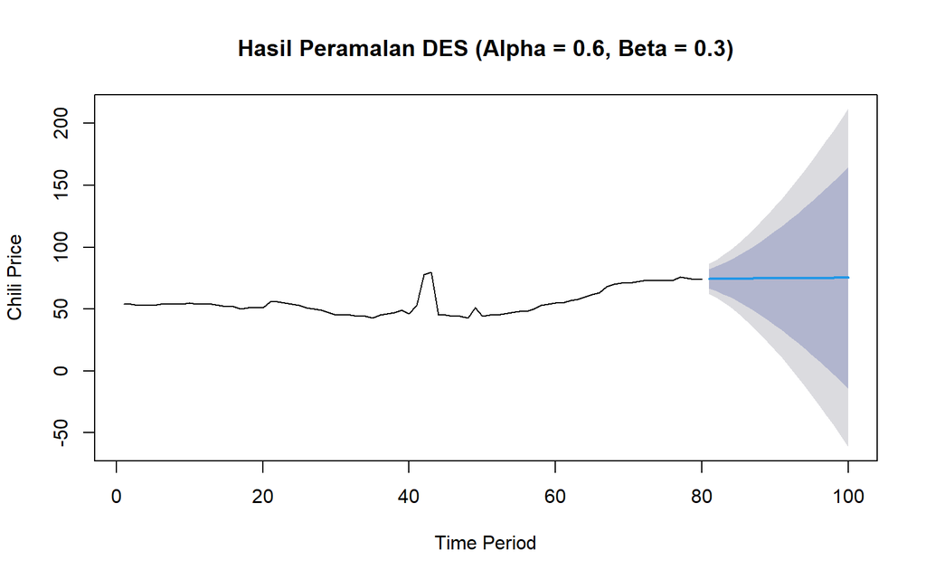

```r
plot(ramalandes2, main = "Hasil Peramalan DES (Alpha = 0.6, Beta = 0.3)", ylab = "Chili Price", xlab = "Time Period")
```

## membandingkan plot data latih dan data uji

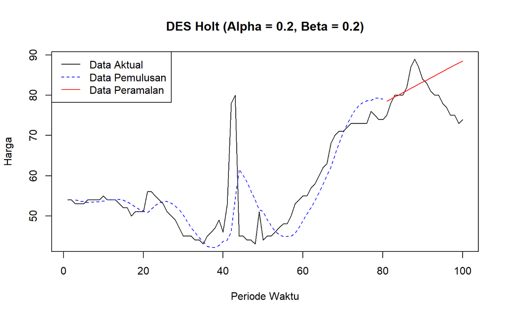

```r
plot(data1.ts,
     main = "DES Holt (Alpha = 0.2, Beta = 0.2)",
     ylab = "Harga",
     xlab = "Periode Waktu")

lines(des.1$fitted[,1], lty=2, col="blue")
lines(ramalandes1$mean, col="red")

legend("topleft",
       legend = c("Data Aktual", "Data Pemulusan", "Data Peramalan"),
       lty = c(1, 2, 1),
       col = c("black", "blue", "red"))
```

## nilai parameter optimum dari DES

```r
des.opt <- HoltWinters(train_ma.ts, gamma = FALSE)
des.opt
```

```
## Holt-Winters exponential smoothing with trend and without seasonal component.
##
## Call:
## HoltWinters(x = train_ma.ts, gamma = FALSE)
##
## Smoothing parameters:
##  alpha: 1
##  beta : 0
##  gamma: FALSE
##
## Coefficients:
##   [,1]
## a   74
## b    0
```

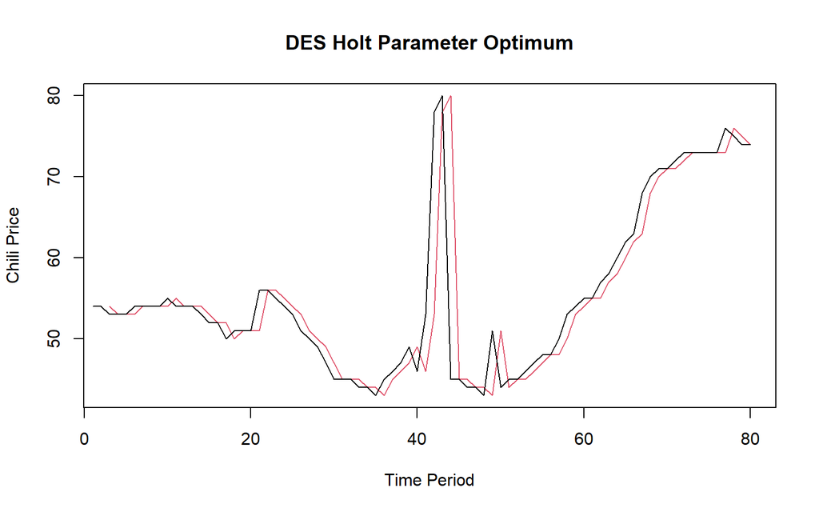

```r
plot(des.opt, main = "DES Holt Parameter Optimum", ylab = "Chili Price", xlab = "Time Period")
```

```r
ramalandesopt <- forecast(des.opt, h = length(test_ma.ts))
ramalandesopt
```

```
##     Point Forecast    Lo 80     Hi 80    Lo 95     Hi 95
##  81             74 67.20787  80.79213 63.61233  84.38767
##  82             74 64.39447  83.60553 59.30962  88.69038
##  83             74 62.23568  85.76432 56.00803  91.99197
##  84             74 60.41574  87.58426 53.22466  94.77534
##  85             74 58.81233  89.18767 50.77247  97.22753
##  86             74 57.36274  90.63726 48.55551  99.44449
##  87             74 56.02971  91.97029 46.51681 101.48319
##  88             74 54.78895  93.21105 44.61923 103.38077
##  89             74 53.62360  94.37640 42.83699 105.16301
##  90             74 52.52139  95.47861 41.15131 106.84869
##  91             74 51.47305  96.52695 39.54800 108.45200
##  92             74 50.47136  97.52864 38.01606 109.98394
##  93             74 49.51062  98.48938 36.54673 111.45327
##  94             74 48.58617  99.41383 35.13290 112.86710
##  95             74 47.69419 100.30581 33.76873 114.23127
##  96             74 46.83147 101.16853 32.44932 115.55068
##  97             74 45.99532 102.00468 31.17054 116.82946
##  98             74 45.18342 102.81658 29.92885 118.07115
##  99             74 44.39378 103.60622 28.72120 119.27880
## 100             74 43.62466 104.37534 27.54493 120.45507
```

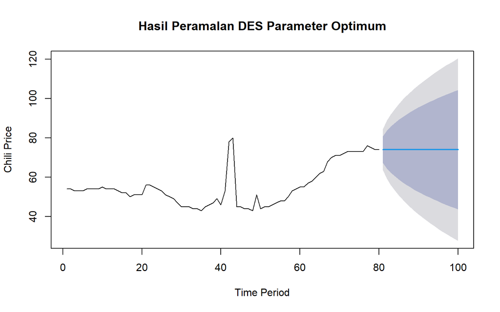

```r
plot(ramalandesopt, main = "Hasil Peramalan DES Parameter Optimum", ylab = "Chili Price", xlab = "Time Period")
```

## Akurasi data latih

```r
ssedes.train1  <- des.1$SSE
msedes.train1  <- ssedes.train1 / length(train_ma.ts)
rmsedes.train1 <- sqrt(msedes.train1)
mapedes.train1 <- mean(abs(residuals(des.1) / train_ma.ts) * 100, na.rm = TRUE)

ssedes.train2  <- des.2$SSE
msedes.train2  <- ssedes.train2 / length(train_ma.ts)
rmsedes.train2 <- sqrt(msedes.train2)
mapedes.train2 <- mean(abs(residuals(des.2) / train_ma.ts) * 100, na.rm = TRUE)

ssedes.trainopt  <- des.opt$SSE
msedes.trainopt  <- ssedes.trainopt / length(train_ma.ts)
rmsedes.trainopt <- sqrt(msedes.trainopt)
mapedes.trainopt <- mean(abs(residuals(des.opt) / train_ma.ts) * 100, na.rm = TRUE)

# Tabel Ringkas
akurasitrain_des <- matrix(
  c(ssedes.train1, msedes.train1, rmsedes.train1, mapedes.train1,
    ssedes.train2, msedes.train2, rmsedes.train2, mapedes.train2,
    ssedes.trainopt, msedes.trainopt, rmsedes.trainopt, mapedes.trainopt),
  nrow = 4,
  byrow = FALSE,
  dimnames = list(c("SSE", "MSE", "RMSE", "MAPE (%)"),
                  c("Alpha=0.2 & Beta=0.2", "Alpha=0.6 & Beta=0.3", "DES Optimum"))
)

akurasitrain_des
```

```
##          Alpha=0.2 & Beta=0.2 Alpha=0.6 & Beta=0.3 DES Optimum
## SSE               3641.570867          2911.389016 2168.000000
## MSE                 45.519636            36.392363   27.100000
## RMSE                 6.746824             6.032608    5.205766
## MAPE (%)             7.869602             4.952851    3.722193
```

Hasil akurasi dari data latih didapatkan model DES Optimum memiliki hasil yang lebih baik. Namun untuk kedua model lainnya dapat dikategorikan peramalan sangat baik berdasarkan nilai MAPE-nya.

## Akurasi data uji

```r
selisihdes1   <- as.numeric(ramalandes1$mean) - as.numeric(test_ma.ts)
selisihdes2   <- as.numeric(ramalandes2$mean) - as.numeric(test_ma.ts)
selisihdesopt <- as.numeric(ramalandesopt$mean) - as.numeric(test_ma.ts)

SSEtestingdes1  <- sum(selisihdes1^2, na.rm = TRUE) # (Alpha = 0.2, Beta = 0.2)
MSEtestingdes1  <- mean(selisihdes1^2, na.rm = TRUE)
RMSEtestingdes1 <- sqrt(MSEtestingdes1)
MAPEtestingdes1 <- mean(abs(selisihdes1 / as.numeric(test_ma.ts)) * 100, na.rm = TRUE)

SSEtestingdes2  <- sum(selisihdes2^2, na.rm = TRUE) # (Alpha = 0.6, Beta = 0.3)
MSEtestingdes2  <- mean(selisihdes2^2, na.rm = TRUE)
RMSEtestingdes2 <- sqrt(MSEtestingdes2)
MAPEtestingdes2 <- mean(abs(selisihdes2 / as.numeric(test_ma.ts)) * 100, na.rm = TRUE)

SSEtestingdesopt  <- sum(selisihdesopt^2, na.rm = TRUE) # DES Optimum
MSEtestingdesopt  <- mean(selisihdesopt^2, na.rm = TRUE)
RMSEtestingdesopt <- sqrt(MSEtestingdesopt)
MAPEtestingdesopt <- mean(abs(selisihdesopt / as.numeric(test_ma.ts)) * 100, na.rm = TRUE)

# Tabel Ringkas
akurasitestingdes <- matrix(
  c(SSEtestingdes1, MSEtestingdes1, RMSEtestingdes1, MAPEtestingdes1,
    SSEtestingdes2, MSEtestingdes2, RMSEtestingdes2, MAPEtestingdes2,
    SSEtestingdesopt, MSEtestingdesopt, RMSEtestingdesopt, MAPEtestingdesopt),
  nrow = 4,
  byrow = FALSE,
  dimnames = list(c("SSE", "MSE", "RMSE", "MAPE (%)"),
                  c("Alpha=0.2 & Beta=0.2", "Alpha=0.6 & Beta=0.3", "DES Optimum"))
)

akurasitestingdes
```

```
##          Alpha=0.2 & Beta=0.2 Alpha=0.6 & Beta=0.3 DES Optimum
## SSE               1064.006970           917.952394 1082.000000
## MSE                 53.200349            45.897620   54.100000
## RMSE                 7.293857             6.774778    7.355270
## MAPE (%)             7.071110             6.559121    7.245379
```

Hasil akurasi dari data uji didapatkan model DES dengan $\alpha = 0.6$ dan $\beta = 0.3$ Optimum memiliki hasil yang lebih baik. Namun untuk kedua model lainnya dapat dikategorikan peramalan sangat baik berdasarkan nilai MAPE-nya.

# Perbandingan SES dan DES

```r
MSEfull <-
  matrix(c(MSEtesting1,MSEtesting2,MSEtestingopt,MSEtestingdes1,MSEtestingdes2,
           MSEtestingdesopt),nrow=3,ncol=2)
row.names(MSEfull)<- c("ske 1", "ske 2", "ske opt")
colnames(MSEfull) <- c("ses","des")
MSEfull
```

```
##              ses      des
## ske 1   66.17692 53.20035
## ske 2   53.97385 45.89762
## ske opt 54.10000 54.10000
```